# Assignment 1

Johanna Lee

2024-06-10

# 1 Quiz 1 Feedback

### Q4:

The students whose parents consented will be randomized to single-sex or coed classes. What will be true of study results?  
*I chose*: Neither of the above  
*Right answer*: We can conclude that single-sex v. coed classroom type causes any differences in outcomes  
I thought that “outcome” implied the target population, but it just means our sample, and since we randomized treatment, we can reach this conclusion.

### Q7:

Based on those same two paragraphs, what value of the test statistic is the cutoff for rejecting the null?  
*I chose*:6  
*Right answer*:8  
Didn’t read the article thoroughly…

### Q10:

Suppose that you conducted a randomized experiment, assigning 50 people to treatment and 50 people to control by drawing names from a hat. After collecting outcomes, you conduct a randomization test, using the ratio of the two group medians as a test statistic. What is the simplest way to generate a reference distribution?  
*I chose*:Approximating the reference distribution with a normal distribution with a certain mean and variance  
*Right answer*:Randomly simulating 1000 ways to assign 100 people to two groups of 50  
simplest way would be SRS. Also, there is no guarantee that the reference distribution is normal, and even if it is, not clear how we’ll come up with the mean and variance because we’re not using rank sum test.

# 2 RailTrail Dataset

```r
library(mosaicData)
dim(RailTrail)
```

```
## [1] 90 11
```

```r
#head(RailTrail,20)
RailTrail[1:20,-1:-5]
```

```
##    fall cloudcover precip volume weekday dayType
## 1     0        7.6   0.00    501    TRUE weekday
## 2     0        6.3   0.29    419    TRUE weekday
## 3     0        7.5   0.32    397    TRUE weekday
## 4     0        2.6   0.00    385   FALSE weekend
## 5     0       10.0   0.14    200    TRUE weekday
## 6     0        6.6   0.02    375    TRUE weekday
## 7     0        2.4   0.00    417    TRUE weekday
## 8     0        0.0   0.00    629   FALSE weekend
## 9     0        3.8   0.00    533   FALSE weekend
## 10    0        4.1   0.00    547    TRUE weekday
## 11    0        8.5   0.00    432    TRUE weekday
## 12    0        7.2   0.00    418    TRUE weekday
## 13    0       10.0   0.03    193    TRUE weekday
## 14    1        7.7   0.00    331    TRUE weekday
## 15    1        5.8   0.00    280    TRUE weekday
## 16    0        3.6   0.00    304    TRUE weekday
## 17    0        6.1   0.68    352   FALSE weekend
## 18    0        6.3   0.00    156    TRUE weekday
## 19    0        8.6   0.00    365    TRUE weekday
## 20    1       10.0   0.15    181    TRUE weekday
```

```r
summary(RailTrail)
```

```
##     hightemp        lowtemp         avgtemp          spring
##  Min.   :41.00   Min.   :19.00   Min.   :33.00   Min.   :0.0000
##  1st Qu.:59.25   1st Qu.:38.00   1st Qu.:48.62   1st Qu.:0.0000
##  Median :69.50   Median :44.50   Median :55.25   Median :1.0000
##  Mean   :68.83   Mean   :46.03   Mean   :57.43   Mean   :0.5889
##  3rd Qu.:77.75   3rd Qu.:53.75   3rd Qu.:64.50   3rd Qu.:1.0000
##  Max.   :97.00   Max.   :72.00   Max.   :84.00   Max.   :1.0000
##      summer            fall          cloudcover         precip
##  Min.   :0.0000   Min.   :0.0000   Min.   : 0.000   Min.   :0.00000
##  1st Qu.:0.0000   1st Qu.:0.0000   1st Qu.: 3.650   1st Qu.:0.00000
##  Median :0.0000   Median :0.0000   Median : 6.400   Median :0.00000
##  Mean   :0.2778   Mean   :0.1333   Mean   : 5.807   Mean   :0.09256
##  3rd Qu.:1.0000   3rd Qu.:0.0000   3rd Qu.: 8.475   3rd Qu.:0.02000
##  Max.   :1.0000   Max.   :1.0000   Max.   :10.000   Max.   :1.49000
##      volume       weekday          dayType
##  Min.   :129.0   Mode :logical   Length:90
##  1st Qu.:291.5   FALSE:28        Class :character
##  Median :373.0   TRUE :62        Mode  :character
##  Mean   :375.4
##  3rd Qu.:451.2
##  Max.   :736.0
```

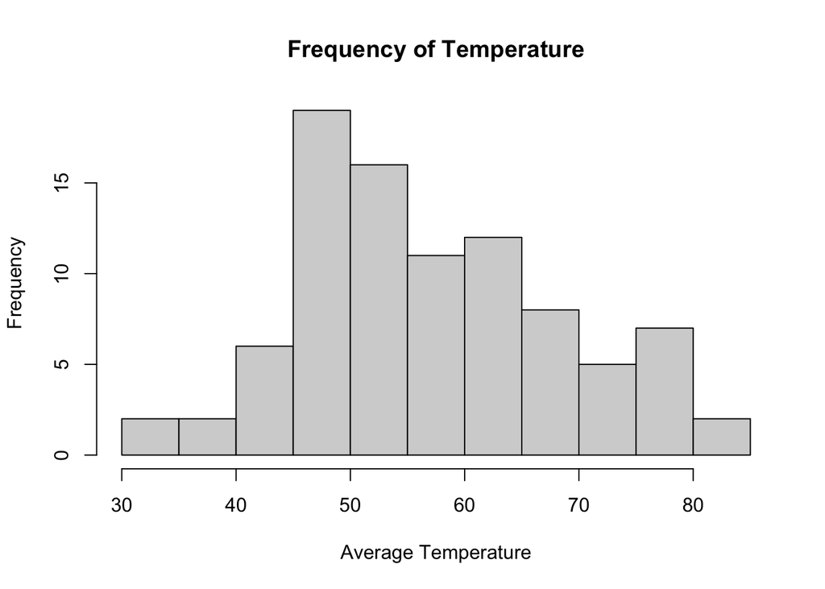

```r
hist(RailTrail$avgtemp, main="Frequency of Temperature", xlab="Average Temperature")
```

[figure not shown]

```r
boxplot(RailTrail$volume, RailTrail$weekday, names=c('weekday','weekend'),main="Number of Trail Users by Type of Day",ylab="volume (# of trail users)")
```

### different plot 1

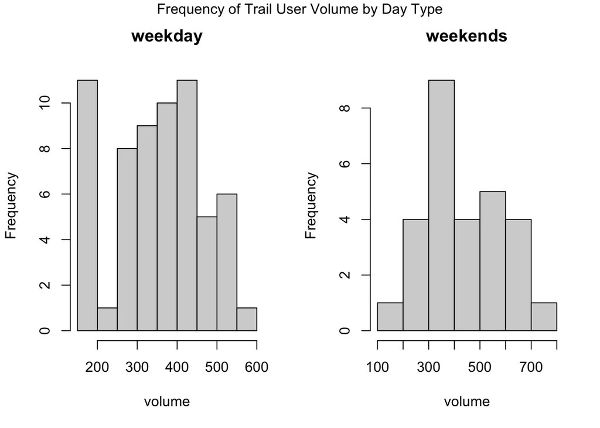

```r
par(mfrow=c(1,2))
hist(RailTrail$volume[RailTrail$weekday == TRUE],main="weekday",xlab="volume")
hist(RailTrail$volume[RailTrail$weekday == FALSE],main="weekends",xlab="volume")
mtext("Frequency of Trail User Volume by Day Type",line=-1, side=3, outer=TRUE)
```

### different plot 2

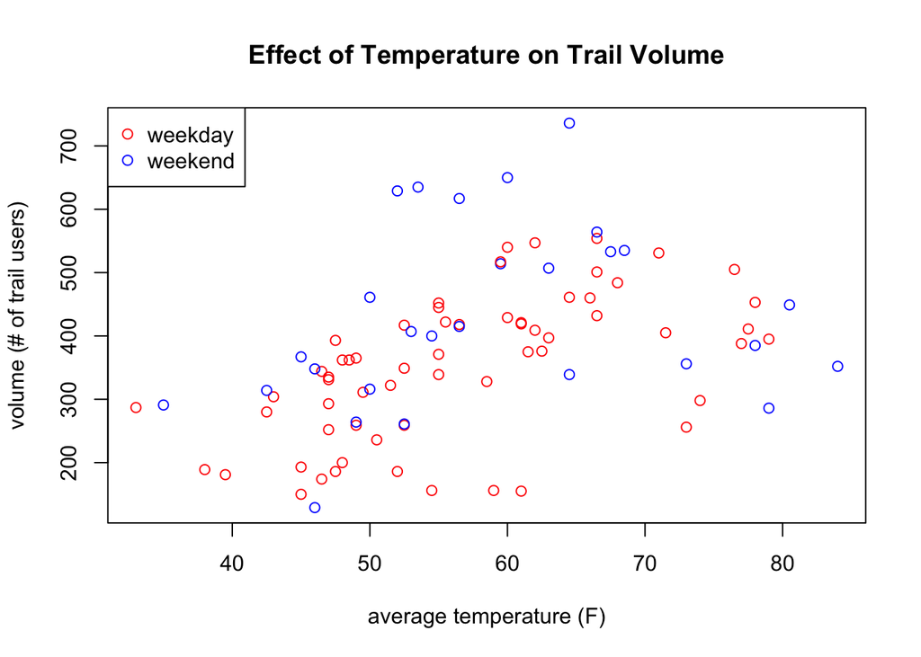

```r
daycolor=ifelse(RailTrail$weekday == TRUE, "red", "blue")
plot(RailTrail$avgtemp,RailTrail$volume, main="Effect of Temperature on Trail Volume",xlab="average temperature (F)", ylab="volume (# of trail users)", col=daycolor)
legend("topleft",col=c("red","blue"),legend=c("weekday","weekend"), pch =1 )
```

# 3

Consider a research project that you have worked on or thought about recently. Perhaps it’s a study you read about in the news. Answer each of the questions below in a sentence or two, or guess and discuss if you are not sure.  
*(a) Briefly describe the project and its goals.*  
Project: Wellesley Cred Lab Paper I read recently – The Media Coverage of the 2020 US Presidential Election Candidates through the Lens of Google’s Top Stories  
*(b) How is a “unit” defined?*  
Article in the Google Top Stories panel  
*(c) What is the target population?*  
Article in the Google Top Stories panel when the query searched on Google is a US presidential election candidate name  
*(d) What is the sample population?*  
Google Top Stories panel of politicians involved in the 202 US Presidential Election  
*(e) What is the sample? How is the sample selected from the sample population? Briefly discuss any possible sources of selection bias.*  
Google Top Stories panel of 30 US presidential election candidate names. Looked through sports betting websites / articles to manually select 30 names that were rumored to run for the presdiential election. Selection bias: the data collection might have missed a few names, since out of the 60 people that the websites were guessing might run for presidency, only 30 people were selected.  
*(f) Is there any non-response? Briefly discuss any possible sources of non-response bias.*  
I guess there is no non-response in this case, since there has to be a search result page that shows up when the automated browser searches a candidate name on Google.  
*(g) If you are comparing multiple groups, how are units assigned to groups? Briefly discuss any possible sources of bias due to the group assignments.*  
Individually search the 30 names, so there are no groups.  
*(h) Carefully state a definition for your study’s estimand; if you’re not sure of your project’s primary goal, specify a possible estimand. What are the reasons that your estimate will differ from the estimand?*  
Since the RQ is “which news stories are chosen to appear in Top stories and why?”, the estimand the authors are looking for is the news stories in the Top stories for all US Presidential candiates all time. But since the authors can’t infinitely search on Google, the estimate would be to just search the names in an automated browser a few times a day, for a set number of months.  
*(i) Can you think of any ethical concerns related to this study?*  
Since the study is scraping the internet, a ethical concern would be copyright – the reporters that wrote the articles or the publisher do not know they were part of the study.

# 4

*(a)* Having signs up don’t look that significant, since 160 > 140 although 100 is the smallest out of the four.  
Bates Claflin StoneD Tower  
100 160. 140. 180 diff b/w mean outcome (S-N)  
S S N N 130 - 160 = -30  
S N N S 140 - 150 = -10  
N N S S 160 - 130 = 30  
N S N S 170 - 120 = 50  
N S S N 150 - 140 = 10  
S N S N 120 - 170 = -50  
*one sided p-value*: 2/6 = 1/3  
We do not have enough evidence to rule out the possibility that signs have no effect on energy usage with a one sided left p-value of 1/3.

*(b)*

```r
library(perm)
sign = c(100,160)
nosign = c(140,180)
```

```r
permTS(sign,nosign,alternative="less")
```

```
##
##  Exact Permutation Test (network algorithm)
##
## data:  sign and nosign
## p-value = 0.3333
## alternative hypothesis: true mean sign - mean nosign is less than 0
## sample estimates:
## mean sign - mean nosign
##                     -30
```

other p-values

```r
permTS(sign,nosign,alternative="greater")
```

```
##
##  Exact Permutation Test (network algorithm)
##
## data:  sign and nosign
## p-value = 0.8333
## alternative hypothesis: true mean sign - mean nosign is greater than 0
## sample estimates:
## mean sign - mean nosign
##                     -30
```

```r
permTS(sign,nosign,alternative="two.sided")
```

```
##
##  Exact Permutation Test (network algorithm)
##
## data:  sign and nosign
## p-value = 0.6667
## alternative hypothesis: true mean sign - mean nosign is not equal to 0
## sample estimates:
## mean sign - mean nosign
##                     -30
```

yes, the one-sided left p-value is 0.33, which is what we manually calculated above. The two-sided p-value is indeed 2*one-sided smaller p-value.

*(c)* Bates Claflin StoneD Tower  
1 3 2 4 rank sum  
S S N N 4  
S N N S 5  
N N S S 6  
N S N S 7  
N S S N 5  
S N S N 3

*one sided p-value*: 2/6 = 1/3

```r
wilcox.test(sign,nosign,alternative="less")
```

```
##
##  Wilcoxon rank sum exact test
##
## data:  sign and nosign
## W = 1, p-value = 0.3333
## alternative hypothesis: true location shift is less than 0
```